# Univariate analysis: Fits and residuals

This tutorial makes use of the following R package(s): **`ggplot2`**, **`dplyr`**, **`lattice`**.

This material is intended to supplement **pages 34 to 41** of **Cleveland’s book**.

In previous lectures, we’ve determined that the `voice.part` singer groups differed only by location (central value) and not so much by spread. In this section, we will expand this analysis by **fitting** a model to our data then exploring the residuals.

# Fitting the data

Univariate data can be characterized by their location and by their spread. The different groups of singers differed by their central values, we will therefore **fit** the group means to each group batch and compare the **residuals** between groups.

First, we’ll load the libraries that will be used in this exercise, then load the `singer` data into the object `df`.

```r
library(dplyr)
library(ggplot2)

df <- lattice::singer
```

Next, we’ll plot the singer values using jittered points, then add an orange point to each batch which will represent each group’s mean.

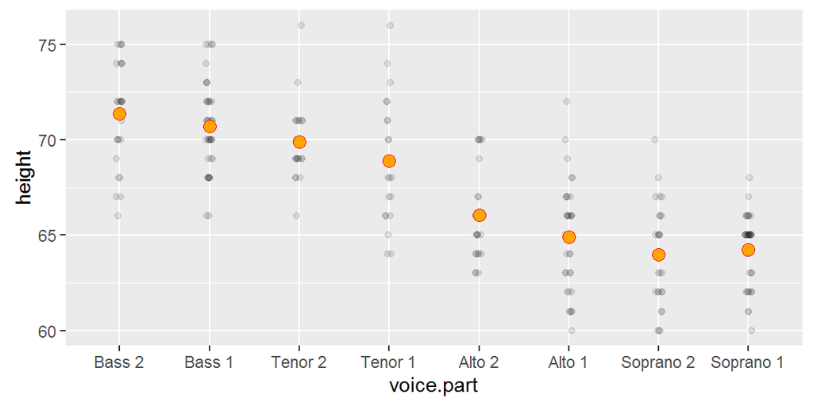

```r
ggplot(df, aes(y=height, x=voice.part))         +
  geom_jitter(width = 0.1, height=0, alpha=0.1) +
  stat_summary(fun.y = "mean", col="red", geom="point", cex=3, pch=21, bg="orange")
```

We’ve **fitted** each group with the **mean**–a mathematical description of the batches. Note that we could have used other measures of location such as the median, but since the data seem to follow a normal distribution, the mean is an adequate choice.

# Computing the residuals

Now we’ll subtract the group means from their respective group values: this will give us the **residuals** for each batch.

```r
# Add residual values to the data
df2 <- df %>% group_by(voice.part) %>%
              mutate( Height.res = ( height - mean(height)) )
```

Next, we will generate a plot of the (jittered) residuals.

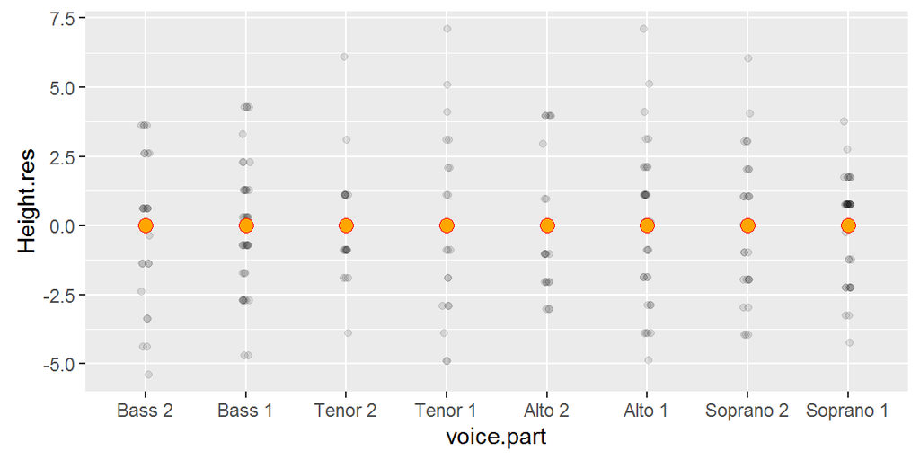

```r
# Now plot the data after fitting height with group mean
ggplot(df2) + aes(y=Height.res, x=voice.part)             +
  geom_jitter(width = 0.1, height=0, alpha=0.1) +
  stat_summary(fun.y = "mean", col="red", geom="point", cex=3, pch=21, bg="orange")
```

We’ve *normalized* the batches to a common location. Note that the values along the y-axis have changed: all values are now spread around `0`. Next, we’ll check that the batches of residuals have similar spread.

# Comparing the residuals

The feature that interests us in the residuals is the **spread**. We’ve learned that a good way to compare spreads is to plot the quantiles of each batch against one another.

## Pairwise q-q plots with the `lattice` package

If we want to compare *all* batches, we can create a pairwise q-q plot using the `lattice` package.

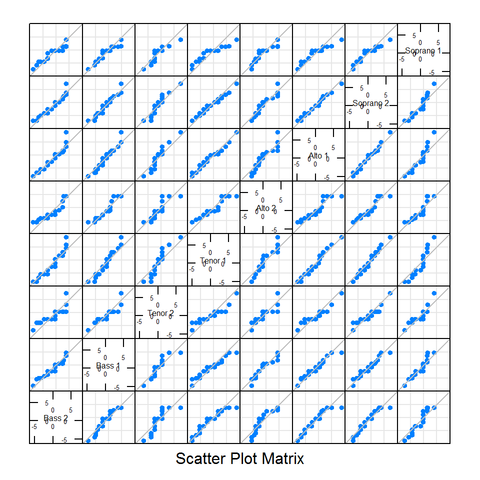

```r
library(lattice)
f.rng <- min(tapply(df2$H, df2$voice.part, length))
fun1  <- function(x,f.rng) {approx(1:length(x), sort(x), n = f.rng )$y}
t1    <- aggregate(df2$H ~ df2$voice.part, FUN=fun1, f.rng=f.rng )
t2    <- as.data.frame(t(t1[,-1]))
names(t2) <- t1[,1]
splom(~t2,  axis.text.cex=0.4, pch = 20,
      varname.cex=0.5,
      pscales=3,
      prepanel.limits = function(x) (range(t2)),
      panel = function(x,y,...){
        panel.grid()
        panel.splom(x,y,...)
        panel.abline(0, 1, col="grey")
      })
```

Note that the plots are symmetrical about the diagonal.

## Comparing batches to pooled residuals

In earlier analyses, it was determined that the spread of the data was homogeneous across the batches, this allows us to combine the residuals and compare the residuals of each batch to the **pooled** residuals.

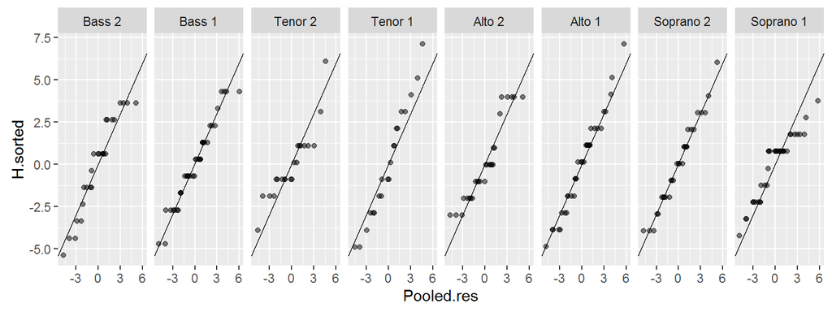

```r
df3 <- df2 %>%
       group_by(voice.part)                     %>%
       mutate(H.sorted = sort(Height.res),
              f.val    = (1:n() - 0.5) / n() )  %>%
       ungroup()                                %>%
       mutate(Pooled.res = quantile(Height.res, f.val))  %>%
       select(voice.part, H.sorted, Pooled.res)


ggplot(df3, aes(y=H.sorted, x=Pooled.res)) + geom_point(alpha=0.5) +
              geom_abline(intercept=0, slope=1) +
              facet_grid(. ~ voice.part)
```

# Comparing pooled residuals to the normal distribution

If we’ve established that the residuals are homogeneous, we can pool the residual values to give us a larger sample size that is then compared with the normal distribution (thus increasing our confidence that the pattern we observe in the plot is real and not subject to random noise that plagues smaller sample sizes).

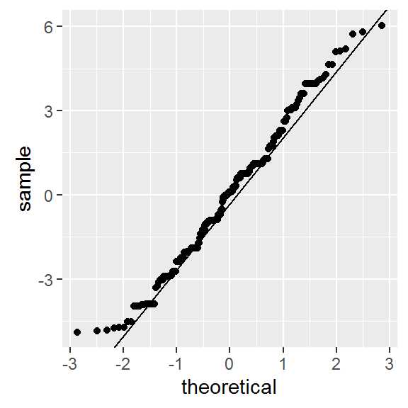

```r
# Find the equation for the line
y     <- quantile(df3$Pooled.res, c(0.25, 0.75))
x     <- qnorm( c(0.25, 0.75))
slope <- diff(y) / diff(x)
int   <- y[1] - slope * x[1]

ggplot(df3, aes(sample=Pooled.res)) +stat_qq() +geom_abline(intercept = int, slope=slope)
```

This dataset has behaved quite well. Its batches differed only by location, yet its spread remained homogeneous (enough) across the batches to pool them and enable us to confirm, with greater confidence, that the spread follows a normal distribution.

The pooled value gives a more accurate measure of spread. We can compute the standard deviation as:

```r
sd(df3$H.sorted)
```

```
[1] 2.465049
```

We can now model singer height by both `voice.part` means, and the group standard deviation of 2.47.

# Residual-fit spread plot

## A simple example

So far, we’ve learned how to fit a model to the data then examine the residuals for homogeneity and normality. But we haven’t assessed if the differences in location (means) between batches is a significant contributor to overall variability in the data. This begs the question, what constitutes significant?

To answer this question, let’s compare the following two plots. Both plots show two batches side-by-side. The difference in location is nearly the same in both plots (group `a` and `b` have a mean of 10 and 11 respectively), but the difference in spreads are not.

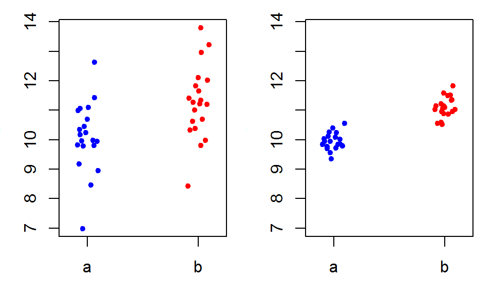

The left-side plot does not allow us to say, with confidence, that the two batches differ significantly despite both means being different. The right-side plot, on the other hand, shows a significant difference in batch locations. So the answer to the question is one of relative spread of the means vs the residuals.

For example, on the right-hand side plot, the *spread* (or difference) in mean values is relatively large compared to the spread of the residuals for each group (note that the spreads are nearly identical between both batches `a` and `b`). The difference in means spans one unit while the spread of each sets of residuals spans about the same amount. So the difference in location is significant.

If we split each batch in the right-side plot into its location component and its pooled residual component and plot those values against a quantile, we get a **residual-fit spread** plot, or **r-f spread** plot for short.

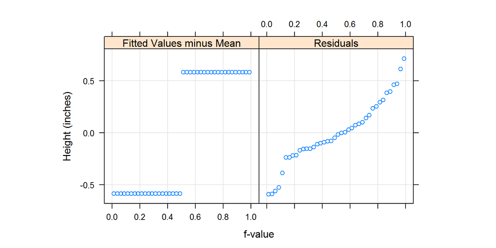

It’s clear from this r-f plot that the spread of the mean distribution (between batches `a` and `b` on the right-side plot) is important compared to that of its residuals.

For the left-side plot, the difference in mean values is also one unit, but the spread of residuals spans almost 5 units. An r-f plot makes this difference quite clear.

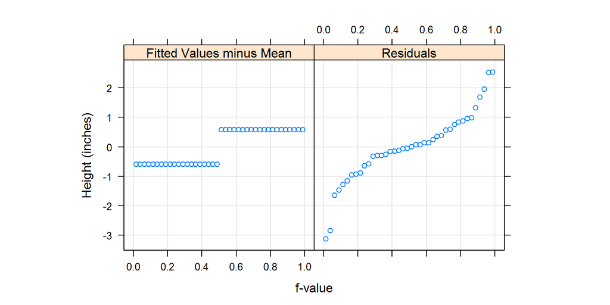

The spread between each batch’s fitted mean is small compared to that of the combined residuals. But this is not to say that the difference in mean values is not real, in fact they are: these data were randomly generated following a normal distribution using *different* means.

## Are the fitted voice part values significantly different?

We’ll use `lattice`’s `rfs` function to generate our r-f plot.

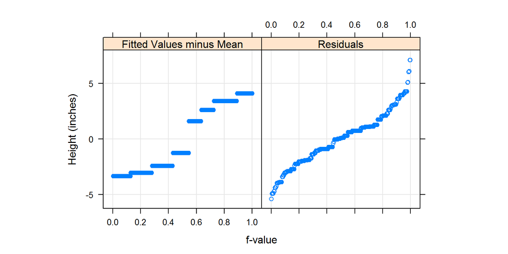

```r
library(lattice)
rfs(oneway(height~voice.part, data = singer, spread = 1),
    aspect=1,
    ylab = "Height (inches)")
```

The spread of the fitted heights (across each voice part) is not insignificant compared to the spread of the combined residuals. So height difference between singer groups cannot be explained by random chance alone; so the voice-part means can explain a good part of the variation in the data.

Manny Gimond (2016)